# Making a web site with R Markdown

## Purpose

This document describes how to create a simple project web site using R Markdown.

There is a very similar workflow for creating a site for an organization (or a person), but we will not provide details here.

## Prerequisites

1. RStudio
2. A GitHub account (optional, but highly recommended).

## Procedure

### Prepare GitHub repo to serve your site (Optional, but highly recommended)

1. Create a new repository (repo) for your site on GitHub.
   - If your repo is a project under your account, it will have the following type of URL: `https://rogilmore.github.io/my-project`.
   - For example, the PSY 525 course is a project under the `psu-psychology` organization, so our site’s URL is `https://psu-psychology.github.io/psy-525-reproducible-research-2020`.
2. Copy/clone the repo to a new project in RStudio.

### Make the website

1. View the [web_site template directory](https://github.com/psu-psychology/psy-525-reproducible-research-2020/how-to/web_site_template/docs) for a skeletal structure you can build on.
2. Essential components of the site are as follows:
   - an `index.Rmd` file that is your home page.
   - a `_site.yml` file that tells RStudio how to render the `.Rmd` and other files into a site.
3. Render the site from your project’s root directory by running `rmarkdown::render_site()`.

### Share the website (via GitHub pages)

1. If your website has its own repo, commit and push all of the code to GitHub.
2. Visit the repo on GitHub.
3. Open the repo’s Settings.
   - Scroll down to the GitHub pages section
4. Choose how GitHub will find your site.
   - `master branch` means that your website files are intermingled with the other files in your repo. This is fine for simple repos, but I usually prefer the second option.
   - `master branch /docs folder`. This means that your website files are copied to a new folder called `docs/`. Here’s a figure showing how the PSY 525 course website is configured.

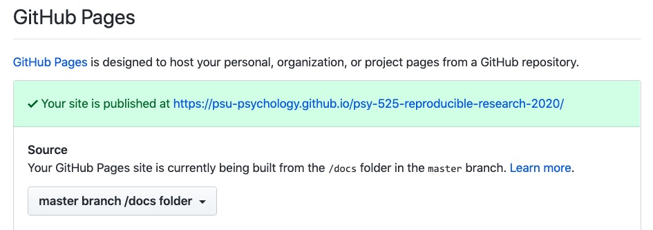

PSY 525 website GitHub pages configuration

```r
knitr::include_graphics("img/github-pages-psy-525.jpg")
```

4. Go back to your R site and confirm that your `_site.yml` file has the correct `output_dir:` parameter.
   - If you chose `master branch` for your GitHub pages, then you must specify `output_dir: "."` in your `_site.yml` header file. The period `.` means the home or root directory for your repo.
   - If you chose `master branch /docs folder` then you must set `output_dir: "docs"` (no `/`).
   - If you change your `_site.yml` file, you must re-render the site using `rmarkdown::render_site()`; commit and push the changes to GitHub.
5. Wait a few moments and then visit the URL for your site. GitHub pages can take tens of seconds to do all the updating on the backend, so be a little patient.

### Share the website via another web hosting service

You can use another web hosting service to host your site. Just copy the files in `docs/` folder or project root directory to that service using whatever instructions your web hosting service provides for uploading content.